# Classification using **L**inear **D**iscriminant **A**nalysis

Dr. Satyakama Paul

October 4, 2018

## Problem statement

- The **bank note authentication dataset** is obtained from the [UCI Machine Learning Repository](https://archive.ics.uci.edu/ml/datasets/banknote+authentication)
- The task is to classify a new note as **REAL** or **FAKE** using LDA.
- The features in the dataset are:

| Feature name | Meaning | Encoded as | Type |
| --- | --- | --- | --- |
| variance | variance of the wavelet transformed image | variance | continuous |
| skewness | skewness of the wavelet transformed image | skewness | continuous |
| kurtosis | kurtosis of the wavelet transformed image | kurtosis | continuous |
| entrophy | entropy of the image | entrophy | continuous |
| class | whether the note is Real or Fake | class | categorical |

## Data fetching and pre-processing

```r
setwd("C:/Users/Paul B/Desktop/great_learning")

master_data <- read.csv("C:/Users/Paul B/Desktop/great_learning/Book2.csv",
                        header = F,
                        sep = ",",
                        na.strings = c("",
                                       "NA"))

#Changing feature names
colnames(master_data) <- c("variance",
                           "skewness",
                           "kurtosis",
                           "entrophy",
                           "class")

str(master_data)
```

```
## 'data.frame':    1372 obs. of  5 variables:
##  $ variance: num  3.622 4.546 3.866 3.457 0.329 ...
##  $ skewness: num  8.67 8.17 -2.64 9.52 -4.46 ...
##  $ kurtosis: num  -2.81 -2.46 1.92 -4.01 4.57 ...
##  $ entrophy: num  -0.447 -1.462 0.106 -3.594 -0.989 ...
##  $ class   : int  0 0 0 0 0 0 0 0 0 0 ...
```

```r
#Checking if there are any missing values in master_data
sum(is.na(master_data))
```

```
## [1] 0
```

```r
#Redefining the class labels
master_data$class <- ifelse(master_data$class =="0",
                            "REAL",
                            "FAKE")

#Changing class label into factor from integer
master_data$class <- as.factor(master_data$class)
```

## Exploratory Data Analysis

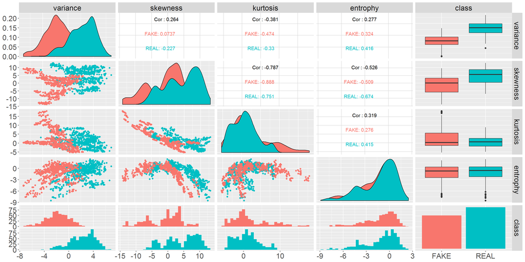

```r
library(tidyverse)
library(GGally)

plot_1 <- master_data %>%
  GGally::ggpairs(data = ., aes(color = class))+
    theme(text = element_text(size=20))

plot_1
```

## Intutive understanding of LDA

### **Maximixing the seperation of projected means**

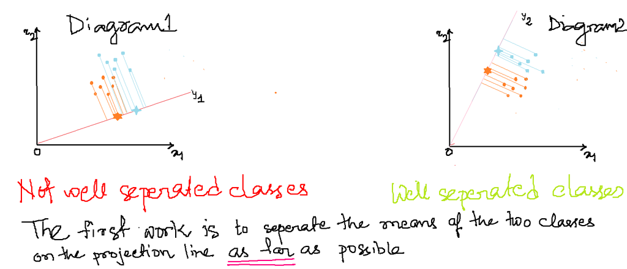

### **Minimizing the scatter within the classes**

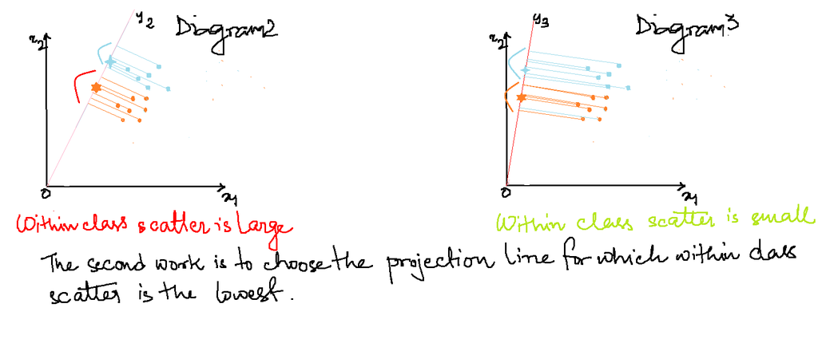

## Mathematical formulation of LDA

Let us assume a $m$ dimensional sample space
$$\{x^{1}, x^{2}, .... , x^{N} \}$$
where $N_{1}$ samples belong to $w_{1}$ class and $N_{2}$ samples belong to $w_{2}$, $N = N_{1}+N_{2}$

Let us also consider a **projection** $y$ such that $y = w^{T}x$ where $x = \begin{bmatrix} x_{1} \\ x_{2} \\ \vdots\\ x_{m} \end{bmatrix}$ and $w = \begin{bmatrix} w_{1} \\ w_{2} \\ \vdots\\ w_{m} \end{bmatrix}$ where $w$ is the projection vector used for projecting $x$ on $y$

**Mean of x in each class**
$$\mu_{i} = \frac{1}{N} \sum_{x \epsilon w_{i}}x$$
and **mean of y in each class**
$$\tilde{\mu_{i}} = \frac{1}{N}\sum_{y \epsilon w_{i}}y = \frac{1}{N}\sum_{x \epsilon w_{i}}w^{T}x = w^{T}\frac{1}{N}\sum_{x\epsilon w_{i}}x = w^{T}\mu_{i}$$

**i.e.projecting x on y** $\Rightarrow$ **projecting the mean of x on the mean of y**

Thus distance between **projected means** can be written as
$$J(w) = |\tilde{\mu_{1}}-\tilde{\mu_{2}}| = |w^{T}\mu_{1} - w^{T}\mu_{2}| = |w^{T}(\mu_{1}-\mu_{2})|$$
In each class, **scatter** or **variability** of a projection is
$$\tilde{s_{i}^{2}} = \sum_{y \epsilon w_{i}}(y - \tilde{\mu_{i}})^{2}$$
and the **within class variability** after projection is $\tilde{s_{1}^{2}}+\tilde{s_{2}^{2}}$

Thus the **objective function** is
*$$J(w) = \frac{|\tilde{\mu_{1}} - \tilde{\mu_{2}}|^{2}}{\tilde{s_{1}^{2}}+\tilde{s_{2}^{2}}}$$*
needs to be maximized wrto. $w$ i.e. $|\tilde{\mu_{1}} - \tilde{\mu_{2}}|^{2}$ needs to be $\Uparrow$ and $\tilde{s_{1}^{2}}+\tilde{s_{2}^{2}}$ needs to be $\Downarrow$

$$\tilde{s_{i}^{2}} = \sum_{y\epsilon w_{i}}(y - \tilde{\mu_{i}})^{2} = \sum_{x\epsilon w_{i}}(w^{T}x - w^{T}\mu_{i})^{2} = \sum_{x\epsilon w_{i}}w^{T}(x - \mu_{i})(x - \mu_{i})^{T}w = w^{T}\Bigg( \sum_{x \epsilon w_{i}}(x - \mu_{i})(x - \mu_{i})^{T}\Bigg)w = w^{T}S_{i}w$$
therefore $\tilde{s_{1}^{2}}+\tilde{s_{1}^{2}} = w^{T}S_{1}w+w^{T}S_{2}w = w^{T}\Bigg(S_{1}+S_{2}\Bigg)w = w^{T}S_{w}w$ where $S_{w}$ is **within class** scatter matrix

Also,
$$\Bigg(\tilde{\mu_{1}} - \tilde{\mu_{2}}\Bigg)^{2} = \Bigg(w^{T}\mu_{1} - w^{T}\mu_{2}\Bigg)^{2} = w^{T}(\mu_{1}-\mu_{2})(\mu_{1}-\mu_{2})^{T}w = w^{T}S_{B}w$$
where $S_{B}$ is **between class** scatter matrix

therefore
$$J(w) = \frac{|\tilde{\mu_{1} -\tilde{\mu_{2}}}|^{2}}{\tilde{s_{1}}^{2} + \tilde{s_{2}}^{2}} = \frac{w^{T}S_{B}w}{w^{T}S_{W}w}$$

$$\frac{d}{dw}J(w) = \frac{d}{dw}\Bigg( \frac{w^{T}S_{B}w}{w^{T}S_{w}w} \Bigg) = 0$$
$$\Rightarrow (w^{T}S_{w}w)\frac{d}{dw}(w^{T}S_{B}w) - (w^{T}S_{B}w)\frac{d}{dw}(w^{T}S_{W}w) = 0$$

## Modeling

```r
library(caret)
library(e1071)

set.seed(123)
index = createDataPartition(y = master_data$class,
                            p=0.75,
                            list=FALSE)

train = master_data[index,]

cat("The number of rows in the training data are",
    dim(train)[1],
    "and the number of columns are",
    dim(train)[2])
```

```
## The number of rows in the training data are 1030 and the number of columns are 5
```

```r
test = master_data[-index,]

cat("The number of rows in the test data are",
    dim(test)[1],
    "and the number of columns are",
    dim(test)[2])
```

```
## The number of rows in the test data are 342 and the number of columns are 5
```

```r
lda.fit = train(class ~ .,
                data=train,
                method="lda",
                trControl = trainControl(method = "repeatedcv",
                                         number=5,
                                         repeats=3,
                                         verboseIter = T,
                                         classProbs = T,
                                         savePredictions = T),
                preProc = c("center", "scale"),
                verbose = F)
lda.fit
```

```
## Linear Discriminant Analysis
##
## 1030 samples
##    4 predictor
##    2 classes: 'FAKE', 'REAL'
##
## Pre-processing: centered (4), scaled (4)
## Resampling: Cross-Validated (5 fold, repeated 3 times)
## Summary of sample sizes: 825, 824, 823, 824, 824, 825, ...
## Resampling results:
##
##   Accuracy   Kappa
##   0.9728042  0.9453269
```

```r
confusionMatrix(reference = test$class,
                predict(lda.fit,
                        newdata = test))
```

```
## Confusion Matrix and Statistics
##
##           Reference
## Prediction FAKE REAL
##       FAKE  152    4
##       REAL    0  186
##
##                Accuracy : 0.9883
##                  95% CI : (0.9703, 0.9968)
##     No Information Rate : 0.5556
##     P-Value [Acc > NIR] : <2e-16
##
##                   Kappa : 0.9764
##  Mcnemar's Test P-Value : 0.1336
##
##             Sensitivity : 1.0000
##             Specificity : 0.9789
##          Pos Pred Value : 0.9744
##          Neg Pred Value : 1.0000
##              Prevalence : 0.4444
##          Detection Rate : 0.4444
##    Detection Prevalence : 0.4561
##       Balanced Accuracy : 0.9895
##
##        'Positive' Class : FAKE
##
```

```r
#Notes:

#Accuracy: Overall how often is the classifier correct

#Sensitivity: When there is an actual event, how often does the classifier predict it as an actual event

#Specificity: When there is an actual non-event, how often does the classifier predict it as a non-event.

#Kappa: Degree of agreement between the classifier and a random generated model.
```

## Decision for new inputs

```r
new_input <- read.csv("C:/Users/Paul B/Desktop/great_learning/new_data.csv",
                      header = T,
                      sep = ",")

new_input <- data.frame(new_input)

predicted_class <- predict(lda.fit,
                           newdata = new_input)

note.number <- seq(1,dim(new_input)[1], 1)
final_prediction <- data.frame(cbind(note.number,
                                     new_input,
                                     predicted_class))

print(require(formattable))
```

```
## [1] TRUE
```

```r
customRed = "#ff7f7f"

formattable(final_prediction,
            align =c("r","c","c","c","c", "c"),
            list(`predicted_class` = formatter("span",
                                               style = ~ style(color = "red",
                                                        font.weight = "bold")),
                 `predicted_class` = color_bar(customRed)))
```

| note.number | variance | skewness | kurtosis | entrophy | predicted_class |
| --- | --- | --- | --- | --- | --- |
| 1 | 0.4305 | 1.975 | 1.3332 | -1.2357 | REAL |
| 2 | -7.0421 | -13.498 | -5.2613 | -8.5482 | FAKE |
| 3 | 6.8248 | 12.952 | 17.9274 | 2.4400 | REAL |